# Chap4_programming_baisc

# 4.0 intro - R prgramming language

### **programming language + data analysis tool**

We teach R because it greatly facilitates data analysis, the main topic of this book. By coding in R, we can efficiently 1) perform exploratory data analysis, 2) build data analysis pipelines and 3) prepare data visualization to communicate results. However, R is not just a data analysis environment but a **programming language**. Advanced R programmers can develop complex **packages** and even improve R itself, but we do not cover advanced programming in this book. Nonetheless, in this section, we introduce three key programming concepts:

```
1. conditional expressions
2. for-loops
3. functions.
```

These are not just key building blocks for advanced programming, but are sometimes useful during data analysis. We also note that there are several functions that are widely used to program in R but that we will not cover in this book. These include `split`, `cut`, `do.call` and `Reduce`. These are worth learning if you plan to become an expert R programmer.

# 4.1 Conditional expressions

Conditional expressions are one of the basic features of programming. They are used for what is called **flow control**. The most common conditional expression is the **if-else statement**. In R, we can actually perform quite a bit of data analysis without conditionals. However, they do come up occasionally, and you will need them *once you start writing your own functions and packages*.

Here is a very simple example showing the general structure of an if-else statement. The basic idea is to print the reciprocal of `a` unless `a` is 0:

```r
a <- 0

if (a!=0){
  print(1/a)
} else{
  print("No reciprocal for 0.")
}
```

```
[1] "No reciprocal for 0."
```

> Check : what is the differences between `a <- 0` and `a = 0`?

Let’s look at one more example using the US murders data frame:

```r
# install dslabs
# install.packages('dslabs')

# import 'dslabs'
## tip : both `library(dslabs)` and `library('dslabs)` is available
library(dslabs)
data(murders)

# calculate murder rate
## note : (dataset)$(name of raw)
murder_rate <- murders$total / murders$population*100000
```

#### **note : [library `dslabs`](https://cran.r-project.org/web/packages/dslabs/index.html)**

##### * Datasets and functions that can be used for data analysis practice, homework and projects in data science courses and workshops. 26 datasets are available for case studies in data visualization, statistical inference, modeling, linear regression, data wrangling and machine learning.

##### * R의 package에는 다른 language와 다르게 dataset이 함께 구성되어 있는 경우도 있다.

Here is a very simple example that tells us `which` states, if any, have a murder rate lower than 0.5 per 100,000. The `if` statement protects us from the case in which no state satisfies the condition.

```r
# indexing minimum value
ind <- which.min(murder_rate)

# murder rate가 최소인 주의 murder rate가 threshold 미만인지 확인
if(murder_rate[ind] < 0.5){
  print(murders$state[ind])
} else{
  print("No state has murder rate that low")
}
```

```
[1] "Vermont"
```

#### **기본함수 : which**

##### 기본형 : which(x, arr.ind=FALSE)

##### 특정 값의 위치를 찾는 함수 (indexing)

##### which.min, which.max : 최솟값과 최댓값 위치를 반환

If we try it again with a rate of 0.25, we get a different answer:

```r
if(murder_rate[ind]<0.25){
  print(murders$state[ind])
} else{
  print("No state has a murder rate that low.")
}
```

```
[1] "No state has a murder rate that low."
```

A related function that is very useful is `ifelse`. This function takes **three arguments: 1) a logical and 2) two possible answers.** If the logical is `TRUE`, the value in the *second argument is returned* and if `FALSE`, the value in the *third argument is returned*. Here is an example:

```r
a <- 0
ifelse(a>0, 1/a, NA)
```

```
[1] NA
```

The function is particularly useful because **it works on vectors**. It examines each entry of the logical vector and returns elements from the vector provided in the second argument, if the entry is `TRUE`, or elements from the vector provided in the third argument, if the entry is `FALSE`.

```r
a <- c(0,1,2,-4,5)
result <- ifelse(a>0, 1/a, NA)
```

##### Is ‘new line’ state essential in R script?

##### Nope. It’s just because of the same variable name.

This table helps us see what happened:

[output not shown]

Here is an example of how this function can be readily used to replace all the missing values in a vector with zeros:

```r
data(na_example)
## replace all the missing values(NA) in a vector with zeros
no_nas <- ifelse(is.na(na_example), 0, na_example)
##is.na : if value == na, TRUE. else, FALSE(0).
sum(is.na(no_nas))
```

```
[1] 0
```

#### **note : what is “na_example”?**

```r
data("na_example")
head(na_example,30)
```

```
 [1]  2  1  3  2  1  3  1  4  3  2  2 NA  2  2  1  4 NA  1  1  2  1  2  2  1  2  5 NA  2  2  3
```

```r
# make random data set
```

Two other useful functions are `any` and `all`. The `any` function takes a vector of logicals and returns `TRUE` if any of the entries is `TRUE`. The `all` function takes a vector of logicals and returns `TRUE` if all of the entries are `TRUE`. Here is an example:

```r
z <- c(TRUE, TRUE, FALSE)
any(z) #1개라도 TRUE이면 TURE
```

```
[1] TRUE
```

```r
all(z) #모두 TRUE여야 TRUE
```

```
[1] FALSE
```

# 4.2 Defining functions

As you become more experienced, you will find yourself needing to perform the same operations over and over. A simple example is computing averages. We can compute the average of a vector `x` using the `sum` and `length` functions: `sum(x)/length(x)`. Because we do this repeatedly, it is much more efficient to write a function that performs this operation. This particular operation is so common that someone already wrote the `mean` function and it is included in **base R**. However, you will encounter situations in which **the function does not already exist**, so R permits you to write your own. A simple version of a function that computes the average can be defined like this:

```r
# `x` stands for independent variable
avg <- function(x){
  s <- sum(x)
  n <- length(x)
  s/n # is identical with `return (s/n)`
}
```

Now `avg` is a function that computes the mean:

```r
# set the variables by slicing `##:###`
x <- 1:100

#identical(x,y) : if `x==y`, TRUE.
identical(mean(x),avg(x))
```

```
[1] TRUE
```

Notice that **variables defined inside a function are not saved in the workspace.** So while we use `s` and `n` when we call `avg`, the values are created and changed only during the call. Here is an illustrative example:

```r
s <- 3
avg(1:10)
```

```
[1] 5.5
```

```r
s
```

```
[1] 3
```

Note how `s` is still 3 after we call `avg`.

In general, **functions are objects**, so we assign them to **variable names with `<-`**. The function `function` tells R you are about to define a function. The general form of a function definition looks like this:

```
my_function <- function(VARIABLE_NAME){
  perform operations on VARIABLE_NAME and calculate VALUE
  VALUE
}
```

The functions you define can have multiple arguments as well as default values. For example, we can define a function that computes either the **arithmetic or geometric average** depending on a user defined variable like this:

```r
avg <- function(x, arithmetic = TRUE){
  n <- length(x)

  ## prod : 벡터 전체 요소의 곱
  ifelse(arithmetic, sum(x)/n, prod(x)^(1/n))
}
```

We will learn more about how to create functions through experience as we face more complex tasks.

# 4.3 Namespaces

So what does R do when we type `filter`? Does it use the **dplyr** function or the **stats** function? From our previous work we know it uses the **dplyr** one. But what if we want to use the **stats** version?

These function live in different *namespaces*. R will follow a certain order when searching for a function in these namespaces. You can see the order by typing:

```r
search()
```

```
 [1] ".GlobalEnv"        "package:dplyr"     "package:dslabs"    "tools:rstudio"
 [5] "package:stats"     "package:graphics"  "package:grDevices" "package:utils"
 [9] "package:datasets"  "package:methods"   "Autoloads"         "package:base"
```

```r
# dplyr >>> stats
```

The first entry in this list is the global environment which includes all the objects you define.

So what if we want to use the **stats** `filter` instead of the **dplyr** `filter` but **dplyr** appears first in the search list? You can force the use of a specific name space by using `double colons (::)` like this:

```
stats::filter()
```

If we want to be absolutely sure we use the **dplyr** `filter` we can use

```
dplyr::filter()
```

Also note that if we want to use a function in a package *without loading the entire package*, we can use the `double colon` as well.

For more on this more advanced topic we recommend the [R packages book](http://r-pkgs.had.co.nz/namespace.html).

# 4.4 For-loops

The formula for the sum of the series $1+2+...+n$ is $n(n+1)/2$. What if we weren’t sure that was the right function? How could we check? Using what we learned about functions we can create one that computes the $S_{n}$:

```r
compute_s_n <- function(n){
  x <- 1:n
  sum(x)
}
```

Perhaps the simplest example of a for-loop is this useless piece of code:

```r
for(i in 1:5){
print(i)
}
```

```
[1] 1
[1] 2
[1] 3
[1] 4
[1] 5
```

Here is the for-loop we would write for our $S_n$ example:

```r
m <- 25
s_n <- vector(length = m) #create an empty vector

for(n in 1:m){
  s_n[n] <- compute_s_n(n)
}
```

In each iteration $n=1$, $n=2$, etc…, we compute $S_n$ and store it in the $n$th entry of `s_n`.

Now we can create a plot to search for a pattern:

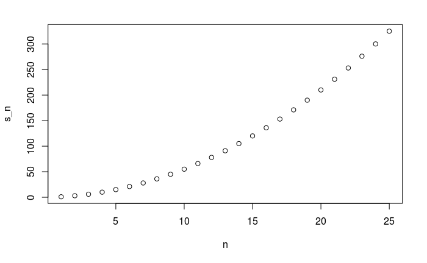

```r
n <- 1:m
plot(n,s_n)
```

If you noticed that it appears to be a quadratic, you are on the right track because the formula is $n(n+1)/2$, which we can confirm with a table:

```r
head(data.frame(s_n = s_n, formula = n*(n+1)/2))
```

|  | s_n | formula |
| --- | --- | --- |
| 1 | 1 | 1 |
| 2 | 3 | 3 |
| 3 | 6 | 6 |
| 4 | 10 | 10 |
| 5 | 15 | 15 |
| 6 | 21 | 21 |

We can also overlay the two results by using the function `lines` to draw a line over the previously plotted points:

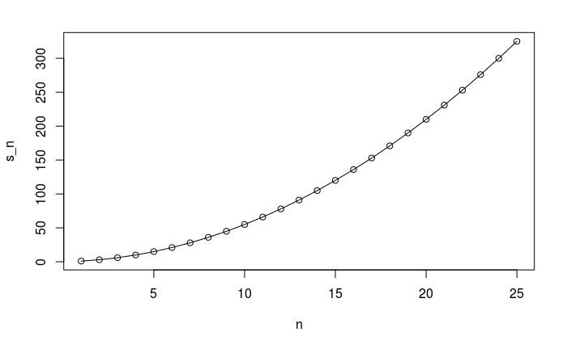

```r
plot(n,s_n)
lines(n, n*(n+1)/2)
```

# 4.5 Vectorization and functionals

Although for-loops are an importnat concept to understand, *in R we rarely use them*. As you learn more R, you will realize that *vectorization* is preferred over for-loops since it results in shorter and clearer code. We already saw examples in the Vector Arithmetic Section. A *vectorized* function is a function that will apply the smae operation on each of the vectors.

```r
x <- 1:10
sqrt(x)
```

```
 [1] 1.000000 1.414214 1.732051 2.000000 2.236068 2.449490 2.645751 2.828427 3.000000 3.162278
```

```r
y <- 1:10
x*y
```

```
 [1]   1   4   9  16  25  36  49  64  81 100
```

To make this calculation, there is no need for for-loops. However, not all functions work this way. For instance, the function we just wrote, `compute_s_n`, does not work **element-wise** since it is expecting a scalar. This piece of code does not run the function on each entry of `n`:

```r
compute_s_n(n)
```

```
numerical expression has 25 elements: only the first used
```

```
[1] 1
```

> `n` is vector, while the independent variable of `compute_s_n` is scalar.

*Functionals* are functions that help us apply the same function to each entry in vector, matrix, data frame or list. Here we cover the functional that operates on numeric, logical and charater vectors : `sapply`.

The function `sapply` permits us to perform element-wise operations on any function. Here is how it works:

```r
x <- 1:10
sqrt(x)
```

```
 [1] 1.000000 1.414214 1.732051 2.000000 2.236068 2.449490 2.645751 2.828427 3.000000 3.162278
```

```r
x <- 1:10
sapply(x, sqrt)
```

```
 [1] 1.000000 1.414214 1.732051 2.000000 2.236068 2.449490 2.645751 2.828427 3.000000 3.162278
```

Each element of `x` is passed on to the function `sqrt` and the result is returned. These results are concatenated. In this case, the result is a vector of the same length as the original `x`. This implies that the for-loop above can be written as follows: `sapply(vector, function for scalar)` **→** return : vector of the dependent variables

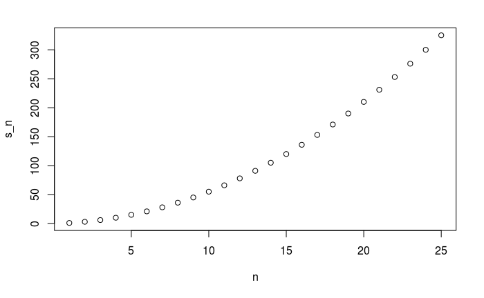

```r
n <- 1:25
s_n <- sapply(n, compute_s_n)
plot(n, s_n)
```

Other functionals are `apply`, `lapply`, `tapply`, `mapply` and `replicate`. We mostly use `sapply`, `apply` and `replicate` in this book, but we **recommend** familiarizing yourselves with the others as they can be very useful.

1. `apply`
2. `lapply`
3. `tapply`
4. `mapply`
5. `replicate`

# 4.6 Exercises

1. What will this conditional expression return?

> “Not all positives”

```r
x <- c(1,2,-3,4)

if(all(x>0)){
  print("All positives")
} else{
  print("Not all positives")
}
```

```
[1] "Not all positives"
```

2. Which of the following expressions is always `FALSE` when at least one entry of a logical vector `x` is TRUE?

A. `all(x)` B. `any(x)` C. `any(!x)` D. `all(!x)`

> Write a line of code that assigns to the object `new_names` the state abbreviation when the state name is longer than 8 characters.

```r
if(nchar(state_name)>8){
  new_names <- state_abb
}
```

```
Error in nchar(state_name) : object 'state_name' not found
```

4. Create a function `sum_n` that for any given value, say $n$, computes the sum of the integers from 1 to n (inclusive). Use the function to determine the sum of integers from 1 to 5,000.

```r
sum_n(n)
```

```
[1] 12502500
```

5. Create a function `altman_plot` that takes two arguments, `x` and `y`, and plots the difference against the sum.

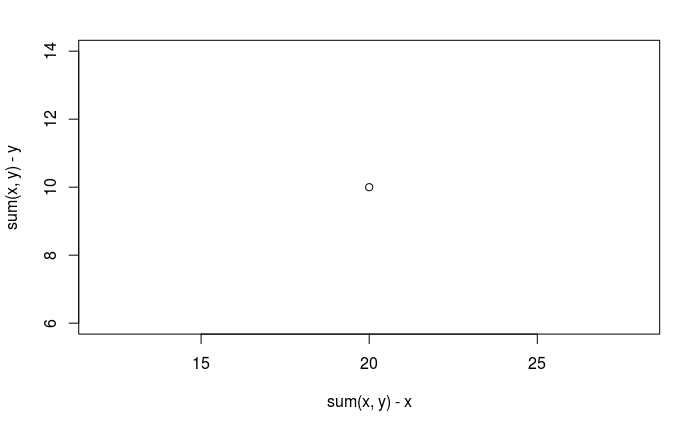

6. After running the code below, what is the value of `x`?

```r
x
```

```
[1] 3
```

> 3
7. Write a function `compute_s_n` that for any given $n$ computes the sum $S_n=1^2+2^2+3^2+...+n^2$. Report the value of the sum when $n=10$.

```r
compute_s_n(n)
```

```
[1] 385
```

8. Define an empty numerical vector `s_n` of size 25 using `s_n <- vector("numeric",25)` and store in the results of $S_1, S_2, ..., S_25$ using for-loop.

```r
s_n
```

```
 [1]    1    5   14   30   55   91  140  204  285  385  506  650  819 1015 1240 1496 1785 2109 2470
[20] 2870 3311 3795 4324 4900 5525
```

9. Repeat exercise 8, but this time use `sapply`.

```r
s_n
```

```
 [1]    1    5   14   30   55   91  140  204  285  385  506  650  819 1015 1240 1496 1785 2109 2470
[20] 2870 3311 3795 4324 4900 5525
```

10. Repeat exercise 8, but this time use `map_dbl`.

```r
map_dbl(1:25, compute_s_n)
```

```
 [1]    1    5   14   30   55   91  140  204  285  385  506  650  819 1015 1240 1496 1785 2109 2470
[20] 2870 3311 3795 4324 4900 5525
```

> note : [why use purrr::map instead lapply](https://stackoverflow.com/questions/45101045/why-use-purrrmap-instead-of-lapply/45994445)
11. Plot $S_n$ versus $n$. Use points defined by $n=1,...25$.

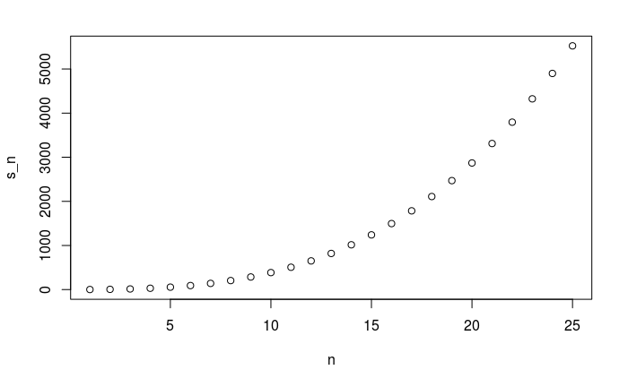

12. Confirm that the formula for this sum is $S_n=n(n+1)(2n+1)/6$

```r
n <- 1:25
print(identical(sapply(n,compute_s_n),sapply(n,formula_s_n)))
```

```
[1] TRUE
```

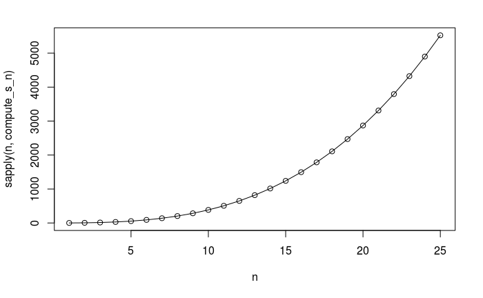